# Bellabeat Case Study

[figure not shown]

# Scenario

In this case study I will be playing the part as a junior data analyst for Bellabeat. As part of the market analytics team I am asked to focus on a Bellabeat product and analyze smart device usage data in order to gain insight into how people are already using their smart devices. Then, using this information, she would like high-level recommendations for how these trends can inform Bellabeat marketing strategy.

# Background Information

### About the Company

- Founded by Urška Sršen and Sando Mur in 2013
- High-tech company that manufactures health-focused smart products for women
- Products used to empower women with knowledge about their own health habits
- Additional information [here](https://bellabeat.com/about/)

### Products

- Bellabeat app: Provides health data on activity, sleep, stress, menstrual cycle, and mindfulness habits.
- Leaf: Classic wellness tracker that can be worn as a bracelet, necklace, or clip.
- Time: Wellness watch used to track user activity, sleep, and stress.
- Spring: Smart waterbottle used to track user hydration throughout the day.
- Bellabeat membership: Subscription membership that gives 24/7 access to fully personalized guidance on nutrition, activity, sleep, health, and mindfulness.

### Steps For Data Analysis

For this analysis I will be following the steps for Data Analysis that was presented in the Google Data Analytics Certificate:

- **Ask:** Identify business task and key stakeholders.
- **Prepare:** Sort and filter data.
- **Process:** Check data for errors, clean the data, transform data for analysis.
- **Analyze:** Organize and format data, perform calculations, identify trends and relationships.
- **Share:** Create data visualizations, present findings, share data.
- **Act:** Present results and recommendations, conclude and explain analysis.

# Ask

### Questions for analysis

1. What are some trends in smart device usage?
2. How could these trends apply to Bellabeat customers?
3. How could these trends help influence Bellabeat marketing strategy?

### Business Task

Identify potential opportunities for growth by observing and identifying trends and relationships of other smart devices. This will be used to gain insight on how customers use our smart devices.

# Prepare

### Load Packages

```r
library(tidyverse)
library(janitor)
library(dplyr)
library(skimr)
library(lubridate)
library(tidyr)
library(openair)
library(ggpubr)
```

### Data

The following data is found from the [Fitbit Fitness Tracker Data](https://www.kaggle.com/arashnic/fitbit) on Kaggle. This data set contains personal fitness tracker information from thirty fitbit users.

```r
dailyActivity <- read.csv("C:/Users/willg/OneDrive/Rstudio/Bellabeat Case Study/Fitabase Data 4.12.16-5.12.16/dailyActivity_merged.csv")

sleepDay <- read.csv("C:/Users/willg/OneDrive/Rstudio/Bellabeat Case Study/Fitabase Data 4.12.16-5.12.16/sleepDay_merged.csv")


hourlySteps <- read.csv("C:/Users/willg/OneDrive/Rstudio/Bellabeat Case Study/Fitabase Data 4.12.16-5.12.16/hourlySteps_merged.csv")

hourlyCalories <- read.csv("C:/Users/willg/OneDrive/Rstudio/Bellabeat Case Study/Fitabase Data 4.12.16-5.12.16/hourlyCalories_merged.csv")

hourlyIntensities <- read.csv("C:/Users/willg/OneDrive/Rstudio/Bellabeat Case Study/Fitabase Data 4.12.16-5.12.16/hourlyIntensities_merged.csv")
```

### Observing the Data

Lets take a quick look at the first few rows of each data set.

```r
head(dailyActivity,3)
```

```
##           Id ActivityDate TotalSteps TotalDistance TrackerDistance
## 1 1503960366    4/12/2016      13162          8.50            8.50
## 2 1503960366    4/13/2016      10735          6.97            6.97
## 3 1503960366    4/14/2016      10460          6.74            6.74
##   LoggedActivitiesDistance VeryActiveDistance ModeratelyActiveDistance
## 1                        0               1.88                     0.55
## 2                        0               1.57                     0.69
## 3                        0               2.44                     0.40
##   LightActiveDistance SedentaryActiveDistance VeryActiveMinutes
## 1                6.06                       0                25
## 2                4.71                       0                21
## 3                3.91                       0                30
##   FairlyActiveMinutes LightlyActiveMinutes SedentaryMinutes Calories
## 1                  13                  328              728     1985
## 2                  19                  217              776     1797
## 3                  11                  181             1218     1776
```

```r
head(hourlyCalories,3)
```

```
##           Id          ActivityHour Calories
## 1 1503960366 4/12/2016 12:00:00 AM       81
## 2 1503960366  4/12/2016 1:00:00 AM       61
## 3 1503960366  4/12/2016 2:00:00 AM       59
```

```r
head(hourlyIntensities,3)
```

```
##           Id          ActivityHour TotalIntensity AverageIntensity
## 1 1503960366 4/12/2016 12:00:00 AM             20         0.333333
## 2 1503960366  4/12/2016 1:00:00 AM              8         0.133333
## 3 1503960366  4/12/2016 2:00:00 AM              7         0.116667
```

```r
head(hourlySteps,3)
```

```
##           Id          ActivityHour StepTotal
## 1 1503960366 4/12/2016 12:00:00 AM       373
## 2 1503960366  4/12/2016 1:00:00 AM       160
## 3 1503960366  4/12/2016 2:00:00 AM       151
```

```r
head(sleepDay,3)
```

```
##           Id              SleepDay TotalSleepRecords TotalMinutesAsleep
## 1 1503960366 4/12/2016 12:00:00 AM                 1                327
## 2 1503960366 4/13/2016 12:00:00 AM                 2                384
## 3 1503960366 4/15/2016 12:00:00 AM                 1                412
##   TotalTimeInBed
## 1            346
## 2            407
## 3            442
```

### Cleaning the Data

Next I will make sure that there are no duplicates in each of the data frames.

```r
sum(duplicated(dailyActivity))
```

```
## [1] 0
```

```r
sum(duplicated(hourlySteps))
```

```
## [1] 0
```

```r
sum(duplicated(hourlyCalories))
```

```
## [1] 0
```

```r
sum(duplicated(hourlyIntensities))
```

```
## [1] 0
```

```r
sum(duplicated(sleepDay))
```

```
## [1] 3
```

I see that sleepDay has 3 duplicates so now I will remove these duplicates so it won’t affect my analysis.

```r
sleepDay <- sleepDay %>%
  distinct() %>%
  drop_na()
```

Now I will check to make sure that the duplicates are removed

```r
sum(duplicated(sleepDay))
```

```
## [1] 0
```

Now I will observe how many distinct Ids there are to see how many users data I am looking at

```r
n_distinct(dailyActivity$Id)
```

```
## [1] 33
```

```r
n_distinct(hourlySteps$Id)
```

```
## [1] 33
```

```r
n_distinct(hourlyCalories$Id)
```

```
## [1] 33
```

```r
n_distinct(hourlyIntensities$Id)
```

```
## [1] 33
```

```r
n_distinct(sleepDay$Id)
```

```
## [1] 24
```

# Process

### Transforming the data

After seeing the columns in each of the data sets I will rename and transform some of the columns to be able to merge them later on.

```r
dailyActivity <- dailyActivity %>%
  rename(date=ActivityDate)

hourlySteps <- hourlySteps %>%
  rename(date=ActivityHour)

hourlyCalories <- hourlyCalories %>%
  rename(date=ActivityHour)

hourlyIntensities <- hourlyIntensities %>%
  rename(date=ActivityHour)

sleepDay <- sleepDay %>%
  rename(date=SleepDay)
```

Now I will transform the date format for merging.

```r
dailyActivity <- dailyActivity %>%
  mutate(date= as.Date(date, format = "%m/%d/%Y"))

hourlySteps <- hourlySteps %>%
  mutate(date= as.POSIXct(date,format ="%m/%d/%Y %I:%M:%S %p" , tz=Sys.timezone()))

hourlyIntensities <- hourlyIntensities %>%
  mutate(date= as.POSIXct(date,format ="%m/%d/%Y %I:%M:%S %p" , tz=Sys.timezone()))

hourlyCalories <- hourlyCalories %>%
  mutate(date= as.POSIXct(date,format ="%m/%d/%Y %I:%M:%S %p" , tz=Sys.timezone()))

sleepDay <- sleepDay %>%
  mutate(date = as.Date(date,format ="%m/%d/%Y %I:%M:%S %p" , tz=Sys.timezone()))
```

Next I will merge the hourly data into one data frame named: hourlyActivity

```r
hourlyActivity <- hourlySteps %>%
  left_join(hourlyIntensities, by=c("Id", "date")) %>%
  left_join(hourlyCalories, by=c("Id", "date"))

head(hourlyActivity)
```

```
##           Id                date StepTotal TotalIntensity AverageIntensity
## 1 1503960366 2016-04-12 00:00:00       373             20         0.333333
## 2 1503960366 2016-04-12 01:00:00       160              8         0.133333
## 3 1503960366 2016-04-12 02:00:00       151              7         0.116667
## 4 1503960366 2016-04-12 03:00:00         0              0         0.000000
## 5 1503960366 2016-04-12 04:00:00         0              0         0.000000
## 6 1503960366 2016-04-12 05:00:00         0              0         0.000000
##   Calories
## 1       81
## 2       61
## 3       59
## 4       47
## 5       48
## 6       48
```

Now I will separate the date into date and time for hourlyActivity.

```r
hourlyActivity <- hourlyActivity %>%
  separate(date, into =c("date", "time"), sep = " ")

head(hourlyActivity)
```

```
##           Id       date     time StepTotal TotalIntensity AverageIntensity
## 1 1503960366 2016-04-12 00:00:00       373             20         0.333333
## 2 1503960366 2016-04-12 01:00:00       160              8         0.133333
## 3 1503960366 2016-04-12 02:00:00       151              7         0.116667
## 4 1503960366 2016-04-12 03:00:00         0              0         0.000000
## 5 1503960366 2016-04-12 04:00:00         0              0         0.000000
## 6 1503960366 2016-04-12 05:00:00         0              0         0.000000
##   Calories
## 1       81
## 2       61
## 3       59
## 4       47
## 5       48
## 6       48
```

# Analyze and Share

In this step I will answer the questions using the data that I have just cleaned and transformed.

Referring back to the questions they are:

1. What are some trends in smart device usage?
2. How could these trends apply to Bellabeat customers?
3. How could these trends help influence Bellabeat marketing strategy?

### Usage each day

First let us start with how many users used the Fitbit each day. I will do this by observing daily step activity and removing the days where there were 0 steps because that means the device was not used.

```r
# Removing 0s
dailyActivity_zero <- filter_at(dailyActivity, vars("TotalSteps"), all_vars((.) !=0))

#Creating a new data frame for number of users by date
dailyUsers <- dailyActivity_zero %>%
  group_by(date) %>%
  summarize(user_perday = sum(n()), .groups="drop")

dailyUsers <- dailyUsers %>%
  mutate(date= as.Date(date, format = "%m/%d/%Y"))
```

I will create a heatmap calendar showing how many users used the Fitbit each day to see if there is any relationship between certain days of the week and number of users as well as if there are any relationships between length of use and number of users.

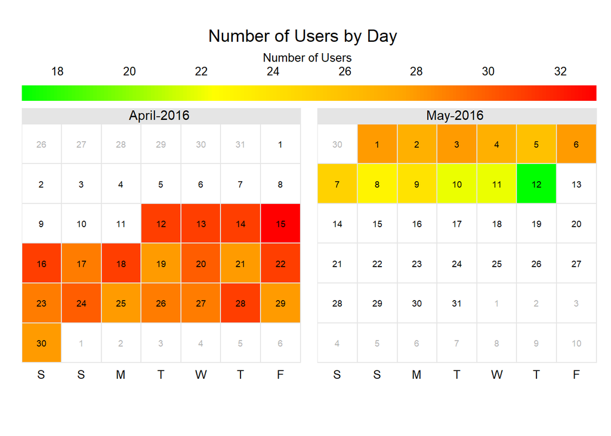

```r
calendarPlot(dailyUsers, pollutant = "user_perday", year = 2016, month = 4:5,  cex.lim = c(0.6, 1), main = "Number of Users by Day", cols=c("green", "yellow", "orange", "red"), key.header = "Number of Users", key.position = "top")
```

```r
options(repr.plot.width = 14, repr.plot.height = 10)
```

```r
summary(dailyUsers$user_perday)
```

```
##    Min. 1st Qu.  Median    Mean 3rd Qu.    Max.
##   17.00   27.00   28.00   27.84   30.50   33.00
```

Looking at the data from the 31 day period I can pinpoint a few key features.

- Of the total 33 Ids observed an average of 28 users use the device on any given day.
- However, looking at the heatmap there is a clear decline in usage during the second half of the period.

### Steps Taken By Weekday

Next I will look at the average amount of steps taken each day of the week. This will be done by grouping the number of steps taken each day and then separating each date into the corresponding day of the week.

```r
dailyActivity_zero <- dailyActivity_zero %>%
    mutate(day = weekdays(as.Date(date, format = "%m/%d/%Y")))

avg_steps_weekday <- dailyActivity_zero %>%
  group_by(day) %>%
  summarize(avg_steps = mean(TotalSteps))

avg_steps_weekday$day <- ordered(avg_steps_weekday$day, levels=c("Monday", "Tuesday", "Wednesday", "Thursday",
"Friday", "Saturday", "Sunday"))

avg_steps_weekday <- avg_steps_weekday %>%
arrange(day)

avg_steps_weekday
```

```
## # A tibble: 7 x 2
##   day       avg_steps
##   <ord>         <dbl>
## 1 Monday        8488.
## 2 Tuesday       8949.
## 3 Wednesday     8158.
## 4 Thursday      8185.
## 5 Friday        7821.
## 6 Saturday      8947.
## 7 Sunday        7627.
```

In the data calculation I used the dailyActivity with 0 values removed because that indicates that the device was not used. This allows me to have a more accurate mean value because it doesn’t take into account the variables with 0 daily steps.

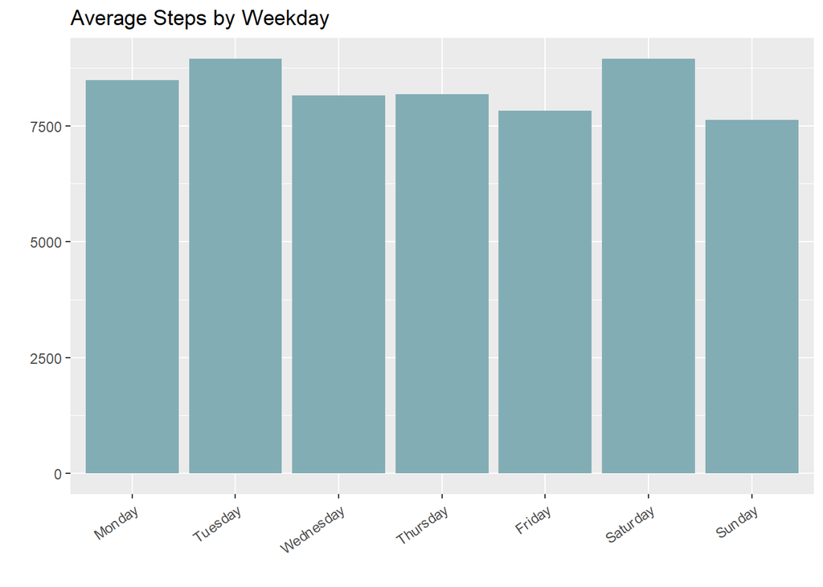

```r
avg_step_bar_chart <- ggplot(avg_steps_weekday) +
  geom_col(aes(x=day, y=avg_steps), fill="#83adb5") +
  labs(title="Average Steps by Weekday", x="", y="") +
  theme(axis.text.x = element_text(angle=35, vjust=1, hjust=1))

avg_step_bar_chart
```

- Friday and Sunday has lower average steps.

### Daily Usage of Device, Day and Night

Next I will observe the daily usage of Fitbits based on the weekday for both during the day (steps) and during the night (sleep). I will use two bar charts and compare the number of uses by day.

```r
step_activity_by_day <- dailyActivity_zero %>%
    group_by(day) %>%
    summarize(days_used = n()) %>%
    arrange(day)

step_activity_by_day$day <-ordered(step_activity_by_day$day, levels=c("Monday", "Tuesday", "Wednesday", "Thursday",
"Friday", "Saturday", "Sunday"))

step_activity_by_day <- step_activity_by_day %>%
    arrange(day)

step_activity_by_day
```

```
## # A tibble: 7 x 2
##   day       days_used
##   <ord>         <int>
## 1 Monday          110
## 2 Tuesday         138
## 3 Wednesday       139
## 4 Thursday        133
## 5 Friday          120
## 6 Saturday        113
## 7 Sunday          110
```

```r
sleep_activity_by_day <- sleepDay %>%
  mutate(day=weekdays(as.Date(date, format="%m/%d/%Y")))

sleep_activity_by_day <- sleep_activity_by_day %>%
  group_by(day) %>%
  summarize(days_used=n()) %>%
  arrange(day)

sleep_activity_by_day$day <- ordered(sleep_activity_by_day$day, levels=c("Monday", "Tuesday", "Wednesday", "Thursday", "Friday", "Saturday", "Sunday"))

sleep_activity_by_day <- sleep_activity_by_day %>%
  arrange(day)

sleep_activity_by_day
```

```
## # A tibble: 7 x 2
##   day       days_used
##   <ord>         <int>
## 1 Monday           46
## 2 Tuesday          65
## 3 Wednesday        66
## 4 Thursday         64
## 5 Friday           57
## 6 Saturday         57
## 7 Sunday           55
```

Next I will put this data into a bar chart and compare them.

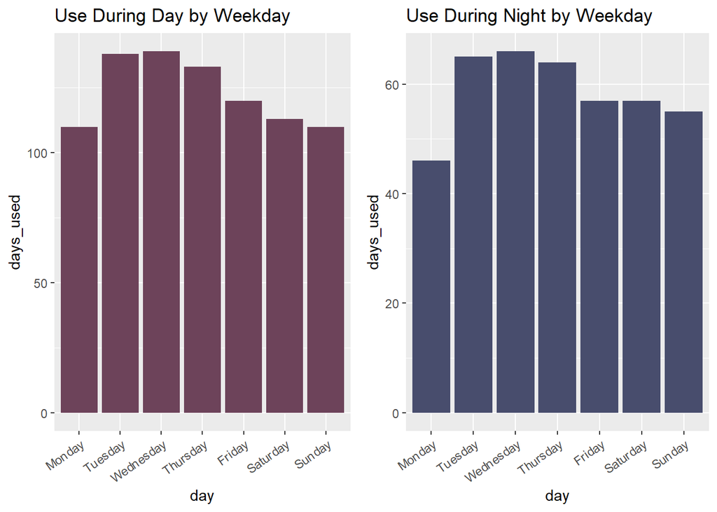

```r
step_activity_by_day_graph <- ggplot(data=step_activity_by_day) +
  geom_col(aes(x=day, y=days_used), fill="#6D435A")+
  labs(title="Use During Day by Weekday") +
  theme(axis.text.x = element_text(angle=35, vjust=1, hjust=1))

sleep_activity_by_day_graph <- ggplot(data=sleep_activity_by_day) +
  geom_col(aes(x=day, y=days_used),fill="#484D6D") +
  labs(title="Use During Night by Weekday") +
  theme(axis.text.x = element_text(angle=35, vjust=1, hjust=1))

ggarrange(step_activity_by_day_graph, sleep_activity_by_day_graph)
```

- More than half the users stop using the Fitbit when sleeping
- Sunday and Monday see a drop in usage compared to the middle of the week

### Daily Steps and Calories

Now I will look at daily steps and calories to see if there is any relationship between the two variables.

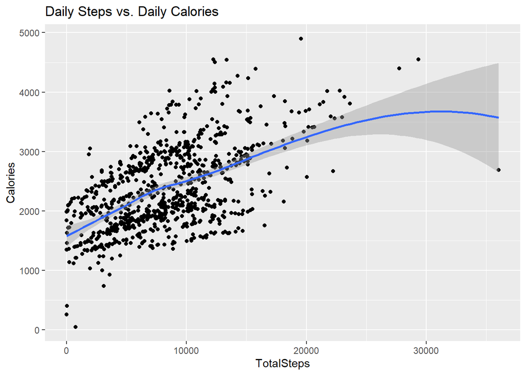

```r
daily_steps_calories_graph <- ggplot(data=dailyActivity_zero)+
  geom_point(aes(x=TotalSteps, y=Calories)) +
  geom_smooth(aes(x=TotalSteps, y=Calories)) +
  ggtitle("Daily Steps vs. Daily Calories")

daily_steps_calories_graph
```

### Sedentary Minutes

Next I will look at sedentary minutes compared to calories and steps as well as total sedentary time per day of the week with scatter points and a smooth graph putting them side by side to observe the relationship between sedentary minutes and steps and calories.

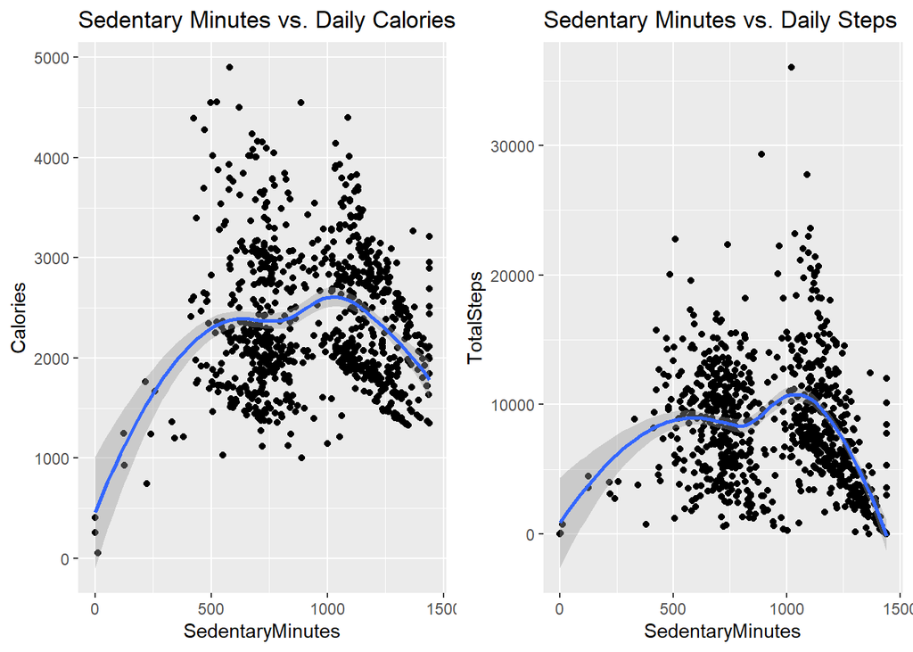

```r
sedentary_calories_graph <- ggplot(data=dailyActivity_zero) +
  geom_point(aes(x=SedentaryMinutes, y=Calories)) +
  geom_smooth(aes(x=SedentaryMinutes, y=Calories)) +
  ggtitle("Sedentary Minutes vs. Daily Calories")

sedentary_steps_graph <- ggplot(data=dailyActivity_zero) +
  geom_point(aes(x=SedentaryMinutes, y=TotalSteps)) +
  geom_smooth(aes(x=SedentaryMinutes, y=TotalSteps)) +
  ggtitle("Sedentary Minutes vs. Daily Steps")

ggarrange(sedentary_calories_graph, sedentary_steps_graph)
```

- Strongly suggests that after about 1000 Sedentary Minutes daily steps and calories burned drop significantly

Now I will look at total Sedentary Minutes for each day of the week.

```r
sedentary_minutes_by_day <- dailyActivity_zero %>%
  mutate(day=weekdays(as.Date(date, format="%m/%d/%Y")))

sedentary_minutes_by_day <- sedentary_minutes_by_day %>%
  group_by(day) %>%
  summarize(avg_sed_min=mean(SedentaryMinutes)) %>%
  arrange(day)

sedentary_minutes_by_day$day <- ordered(sedentary_minutes_by_day$day, levels=c("Monday", "Tuesday", "Wednesday", "Thursday", "Friday", "Saturday", "Sunday"))

sedentary_minutes_by_day <- sedentary_minutes_by_day %>%
  arrange(day)

sedentary_minutes_by_day
```

```
## # A tibble: 7 x 2
##   day       avg_sed_min
##   <ord>           <dbl>
## 1 Monday           990.
## 2 Tuesday          974.
## 3 Wednesday        954.
## 4 Thursday         921.
## 5 Friday           978.
## 6 Saturday         930.
## 7 Sunday           945.
```

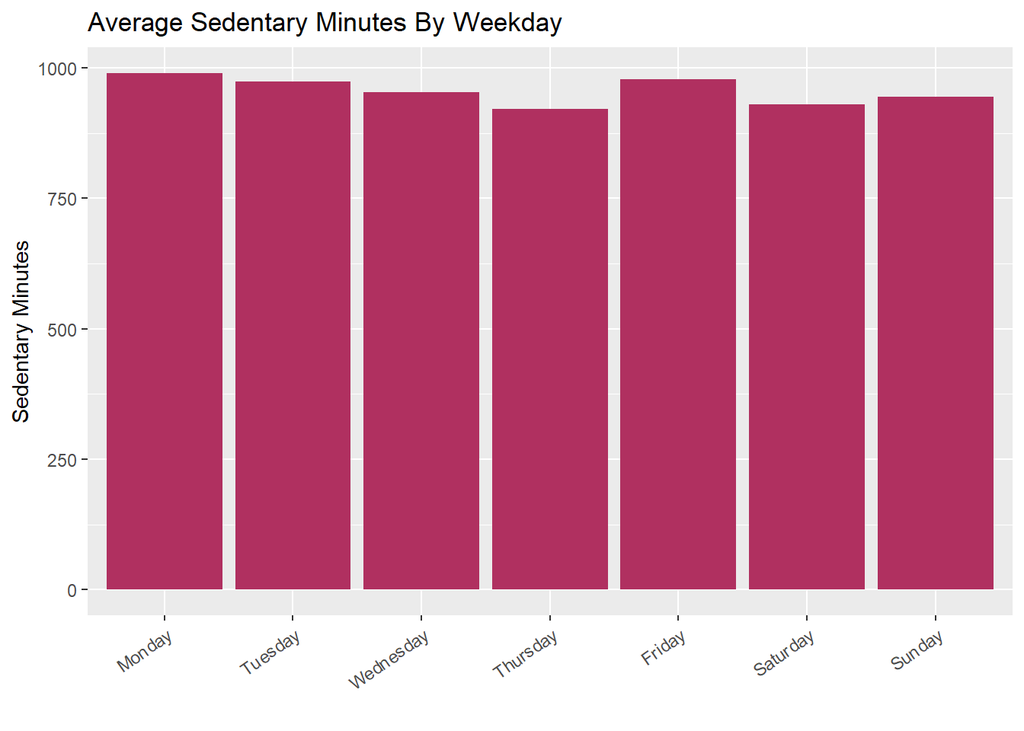

```r
avg_sed_min_chart <- ggplot(sedentary_minutes_by_day) +
  geom_col(aes(x=day, y=avg_sed_min), fill="maroon") +
  labs(title="Average Sedentary Minutes By Weekday", x="", y="Sedentary Minutes") +
  theme(axis.text.x = element_text(angle=35, vjust=1, hjust=1))

avg_sed_min_chart
```

- Monday and Friday have high average sedentary minutes
- Some factors that can contributeis work and relaxation relating to Mondays and Fridays

### Hourly Activity

Finally, I will look at the different levels of hourly activity that could show insight and relationships between variables valuable to our analysis.

```r
step_int_hr <- hourlyActivity %>%
  group_by(time) %>%
  summarize(avg_step_hr=mean(StepTotal), avg_int_hr=mean(TotalIntensity)) %>% arrange(time)

step_int_hr
```

```
## # A tibble: 24 x 3
##    time     avg_step_hr avg_int_hr
##    <chr>          <dbl>      <dbl>
##  1 00:00:00       42.2       2.13
##  2 01:00:00       23.1       1.42
##  3 02:00:00       17.1       1.04
##  4 03:00:00        6.43      0.444
##  5 04:00:00       12.7       0.633
##  6 05:00:00       43.9       4.95
##  7 06:00:00      179.        7.77
##  8 07:00:00      306.       10.7
##  9 08:00:00      428.       14.7
## 10 09:00:00      433.       15.4
## # ... with 14 more rows
```

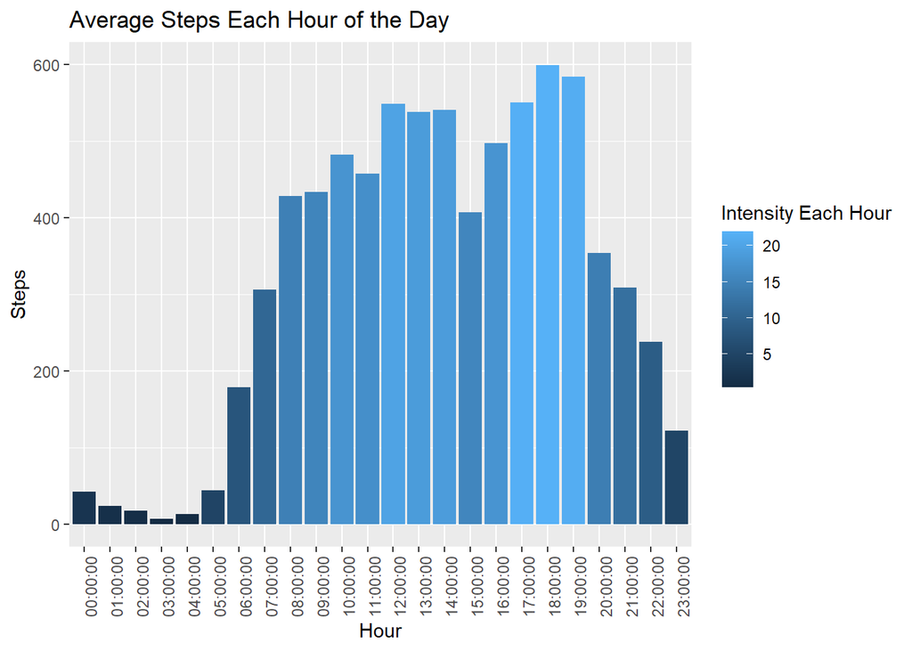

```r
step_hr_chart <- ggplot(data=step_int_hr) +
  geom_col(aes(x=time, y=avg_step_hr, fill=avg_int_hr)) +
  labs(title="Average Steps Each Hour of the Day", x="Hour", y="Steps", fill="Intensity Each Hour") +
  theme(axis.text.x = element_text(angle=90, vjust=1, hjust=1))

step_hr_chart
```

# Act: Recommendations

### Back to the guiding questions

1. What are some trends in smart device usage?
2. How could these trends apply to Bellabeat customers?
3. How could these trends help influence Bellabeat marketing strategy?

### Recommendations

Bellabeat has a lot of tools and data they can use to better their smart technology. However, even with data from other wearable technologies we still must conduct further research using data from our own products. This will give us furhter insight and can provide more accurate information for our customers.